# Module 10 Homework: Mapping and summarizing emergency shelter data

Natalie Nelson, PhD

### Assignment

In this homework assignment, you will wrangle and map the following geospatial data layers (shapefiles):

- [Potential emergency shelters in NC](https://www.nconemap.gov/datasets/potential-emergency-shelters). Potential emergency shelters are sites that can be used as shelters in the event of an emergency. Data layer prepared by the NC DIT Center for Geographic Information and Analysis. File name: `Potential_Emergency_Shelters`.
- [Urban areas in NC](https://www.nconemap.gov/datasets/NCDOT::ncdot-smoothed-urban-boundaries). Data layer prepared by NC Department of Transportation. File name: `NCDOT_Smoothed_Urban_Boundaries_simple`.
- State boundaries (entire U.S.). File name: `state_bounds`.
- NC county boundaries. Prepared by the NC Department of Transportation. File name: `NCDOT_County_Boundaries`.

The primary objective of this homework assignment is to prepare code needed to answer the following questions:

- **How many potential emergency shelter sites are located in urban areas across NC?** Provide your answer as a comment in your R script.
- **How many shelters are located within 50 km of the Capital Area Metropolitan Organization (the name of the urban area surrounding Raleigh)?** Provide an answer in a comment in your script, and prepare code to produce the following map:

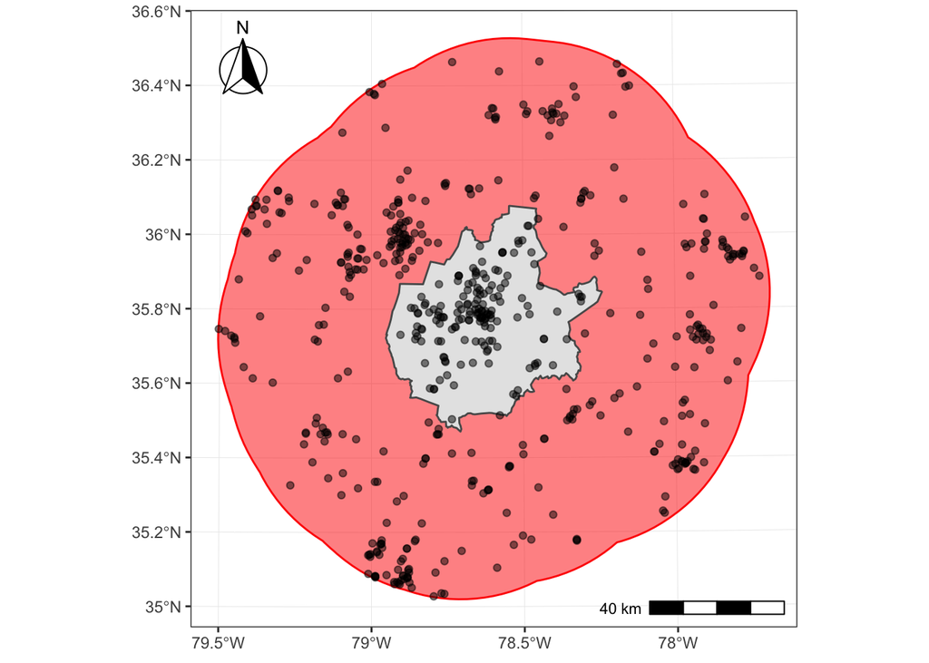

- **How many potential shelters are there per county?** Answer this question by producing the following map:

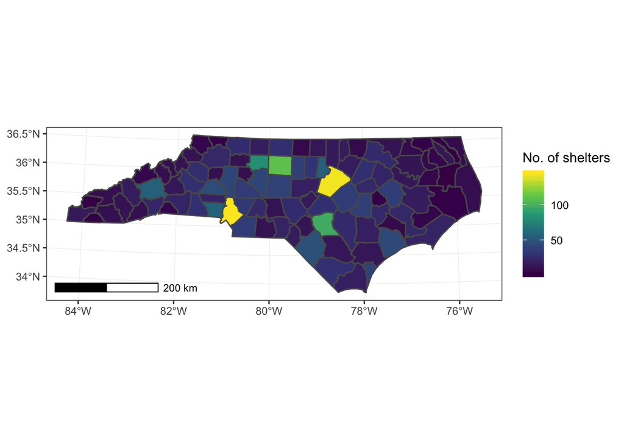

### Extra credit: 10%

**Determine, for urban areas, how many people there are in the area relative to the number of shelters (population / number of shelters).** Note that urban area population values are in the `POP_EST` column in the urban areas file. Create the following plot:

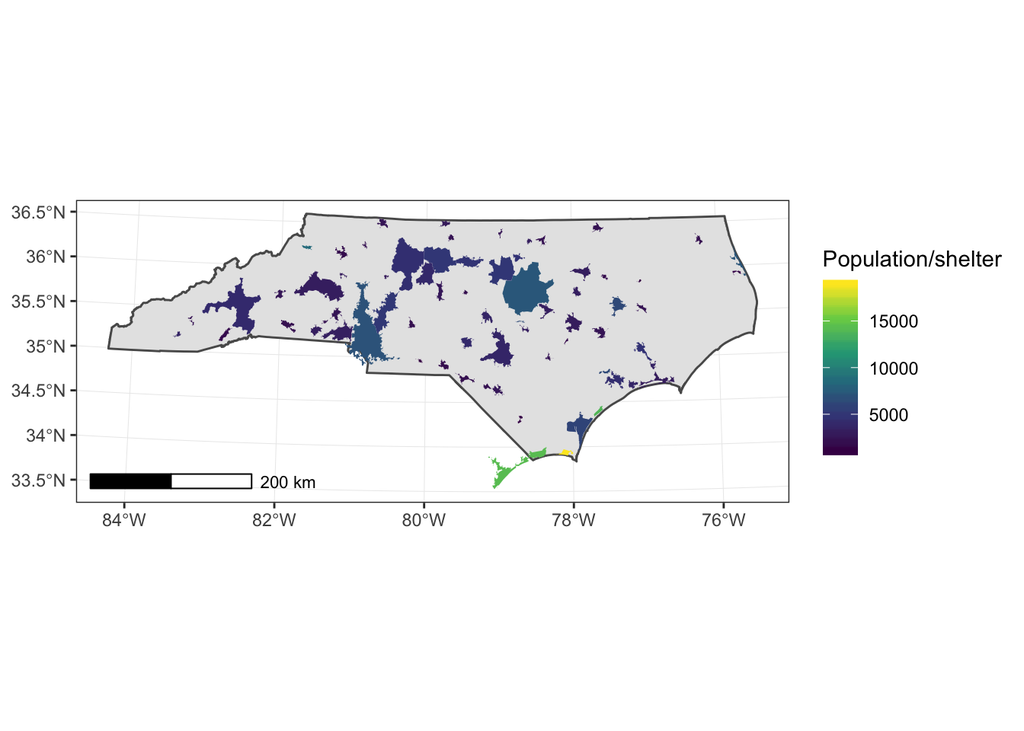

### Submit assignment

To complete this assignment, submit your R script through the assignment posted on the Moodle site. Please keep your code organized and annotated, and include all code to perform the tasks outlined in this assignment.